# Seminario: Problemas Inversos Computacionales – app-mre

## Magnetic Resonance Elastography

Aim: Remote palpation by shear waves, i.e. tomographic quantification of shear modulus of biological tissue.

- Induce excitation at a given frequency (e.g. 50Hz).
- Measure (complex) displacements $\style{color:blue}{\mathbf u(\mathbf x)}$ via MRI (Motion encoding gradient).
- Invert displacements to find shear modulus $\style{color:#d1002d}{G(\mathbf x)}$: viscoelastic properties

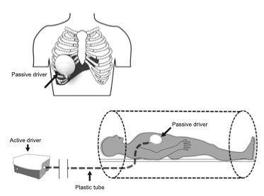

A: T1/T2 weighted} B: $\vert \mathbf u(\mathbf x)\vert$ C: $\vert G(\mathbf x)\vert\qquad$.

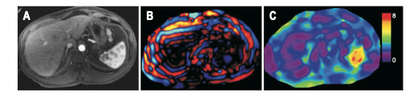

Images From: Tan CH, Venkatesh SK. MRE and Other Magnetic Resonance Imaging Techniques in Chronic Liver Disease: Current Status and Future Directions. Gut and Liver 2016;10:672-686

## Forward/Inverse Problem in MRE

**Forward Model**

Time-harmonic isotropic linear viscoelastic equations
$$\rho \omega^2 \style{color:blue}{\mathbf u} +\nabla \cdot \big[ \style{color:#d1002d}{G} (\nabla \style{color:blue}{\mathbf u} +(\nabla \style{color:blue}{\mathbf u})^{T})\big]+\nabla (\style{color:#d1002d}{\lambda} \nabla \cdot \style{color:blue}{\mathbf u})=\mathbf{0},\qquad \text{in}~ \Omega,$$

- Known quantities: $\omega$ (frequency) and $\rho\approx 10^{3}\text{kg}/\text{m}^3$. \
- Unknown quantities: BCs, $\lambda(\mathbf x)$ and $G(\mathbf x)$
- Measured quantities (via MRI): $\mathbf u_{M}\equiv (\mathbf u(\mathbf x_{1}),\dots,\mathbf u(\mathbf x_{M}))$

**Inverse Problem**

Find the shear modulus $G(\mathbf x)=G_{s}(\mathbf x)+iG_{l}(\mathbf x),$ given measurements of $\mathbf u_{M}\equiv (\mathbf u(\mathbf x_{1}),\dots,\mathbf u(\mathbf x_{M}))$.

$\style{color:#d1002d}{G_{s}(\mathbf x)}$: storage modulus. $\style{color:#d1002d}{G_{l}(\mathbf x)}$: loss modulus.

## Characterisation:

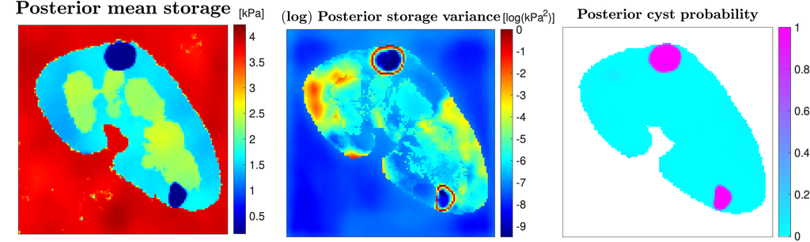

↩︎ Volver al inicio